# Script 4: Selection on Observables

Script 4 Spring 2026

# Recap

## Selection on Observables

Sometimes we cannot randomise treatment. While randomising treatment is the clearly preferable approach - as we learned in the lectures - we still might want to estimate a treatment effect for some interventions or causes we cannot influence. In fact, this might be the case for some of the most interesting research questions in the social sciences.

Simply using observational data comes with all kinds of problems - remember the fundamental problem of causal inference. To mitigate these, we need to assume that, conditional on observable covariates, potential outcomes are the same for treated and untreated units. That is, we must check if treated and untreated units are different in ways we can observe.

Two assumptions are crucial to such designs based on **selection on observables**:

- **Conditional Independence Assumption**

$$(Y_{i1}, Y_{i0}) \perp D_i |
X_i$$

This assumptions maintains that potential outcomes are independent of treatment ($D_i$), conditional on covariates ($X_i$). That is, for the same outcome of the covariates (or the same $X_i$), treatment is as good as random.

- **Common Support Assumption**

$$0 < Pr(D_i=1| X_i=x) <
1$$

This assumptions describes that the probability of treatment is neither 0 nor 1 for a given $X$. There must be variation in the observations we compare to each other: For each level of $X_i$, there are both treated and untreated units.

Note that these assumptions are not the same as the ones we saw under random assignment. Under random assignment, the assumption is:

$$(Y_{i1}, Y_{i0}) \perp D_i$$
which implies that $E[Y_{0i} | D_i = 1] = E[Y_{0i} | D_i = 0]$ and $E[Y_{1i} | D_i = 1] = E[Y_{1i} | D_i = 0]$. In other words, the potential outcomes of all units are the same, regardless of treatment status.

Now, once we select on observables, the **conditional independence assumption** implies that $E[Y_{0i} | D_i = 1, X_i = x] = E[Y_{0i} | D_i = 0, X_i = x]$ and $E[Y_{1i} | D_i = 1, X_i = x] = E[Y_{1i} | D_i = 0, X_i = x]$. In other words, the potential outcomes of all units *with the same* $X_i$ are the same, regardless of treatment status.

Accordingly, we can derive our estimator for the *Conditional Average Treatment Effect (CATE)* as:

$$\Gamma^{SOO} = E[Y_{i1}| X_i = x] -
E[Y_{i0}| X_i = x]$$

Taking the weighted average across $X_i$, we can - in principle - calculate the ATT (note that with endogenous assignment, we can not generalise to the ATE). However, doing this in practice inevitably involves some degree of uncertainty and imprecision. The conditional independence assumption is a very strong assumption - it hardly can be satisfied in practice. First, we cannot account for unobserved variables. As soon as we are working with continuous variables, we are likely to introduce bias as we need to make trade-offs regarding the similarity of observations. One major - more general - obstacle is the **curse of dimensionality**. While we can relatively easily satisfy the condition for one variable (especially if it is binary), this becomes *exponentially* more difficult if we increase the number of variables: We would need a meaningful number of observation for each combination of outcomes.

**Selection on observables should therefore be done with caution. Some treat it as a last-resort approach - using it if and only if randomisation and other identification strategies are not available. However, there might well be cases in which it can be the most credible design to test hypotheses.**

There are two approaches to selecting on observables:

### 1. Multivariate Regression

This one should be familiar to you. Running a multivariate regression means that the estimation of a treatment effect and conditioning on observables happen in a single step.

This is a parametric technique, which often involves extrapolation. That is, outcomes of $X$ that are being compared are not necessarily ‘close’ or similar to each other.

### 2. Matching

As opposed to regressions, balancing coviariates and the estimation of a treatment effect are separated when we apply *Matching* techniques. This allows us to influence *how* balance is being achieved. In other words, we can make adjustments to the process of making units more comparable. We can, for instance, introduce much more narrow restrictions and only compare observations that are *identical* with respect to certain covariates. Think of binary variables and combinations thereof. Matching is a non-parametric estimation technique, which means that assumptions about the functional form we are implicitly making when running regressions do not need to be satisfied here.

There are different ways to match observations, such as using the most similar observation (‘nearest neighbour’), defining bandwidths or propensity scores. We will use a few of these approaches in this script.

**Before starting this seminar**

1. Create a folder called “script4”
2. Download the data (you can use this button or the one at the top, or read csv files directly from github):
3. Open an R script (or Markdown file) and save it in our “script4” folder.
4. Set your working directory using the setwd() function or by clicking on “More”. For example *setwd(“~/Desktop/Causal Inference/2026/script4”)*
5. Let’s install an load packages that we will be using in this script:

```r
library(jtools) # generate plots with regression coefficients
library(stargazer) # generate formated regression tables
library(texreg) # generate formatted regression tables
library(nnet)  # If you want to use glm() to check for balance
library(tidyverse) # to conduct some tidy operations
library(ggplot2) # to generate plots
library(Matching) #provides functions for multivariate and propensity score matching and for finding optimal balance based on a genetic search algorithm.
require(cobalt) # Generate balance tables and plots for covariates of groups preprocessed through matching, weighting or subclassification
```

# Seminar Overview

In this **seminar**, we will cover the following topics:  
1. See that failure to condition on relevant covariates can result in heavily biased (even outrigth wrong) estimates.  
2. Run various multivariate regressions, conditioning on observable covariates.  
3. Test and plot visual evidence for the *common support assumption*.  
4. Learn how to match observations.  
5. Conduct pre and post-balance checks using the `Matching` package.  
6. Apply *propensity score* matching, both without and with replacement.

## The Effect of Daughters on Voting on Women’s Issues

Today, we will be working with data from Ebonya Washington’s work on [**Female Socialization: How Daughters Affect Their Legislator Fathers’ Voting on Women’s Issue**](https://www.aeaweb.org/articles?id=10.1257/aer.98.1.311). In this paper, Washington seeks to answer a behavioural question: *Does having a daughter alter the political attitudes of members of Congress?* To address this question, she develops an identification strategy to reveal the causal effect of having a daughter on liberal voting with regard to issues such as reproductive rights.

Personal circumstances are well known to affect legislators opinions and even voting behaviour. Relatively famous is the case of Ronald Reagan: After being diagnosed with Alzheimer’s his inner circle started advocating in favour of stemm cell research in the hope of finding a cure, although Reagan staunchly rejected any use of stemm cells for ideological reasons throughout his political career.

This paper looks at the behavioural effect children exert on their parents’ political attitudes. Washington specifically looks at the shift in attitudes towards women’s issues that are associated with raising a daughter. She finds clear evidence that parenting a daughter results in a more liberal voting record of members of Congress with regard to several issues, but particularly so for reproductive rights.

Importantly, Washington finds that - conditional on the total number of children - the effect is strong and significant. Obviously, members of Congress differ in several other characteristics as well, not last in terms of political predisposition. She therefore takes into account further personal as well as political characteristics of legislators.

The identification strategy of this paper rests on a few important assumptions:

- The sex of legislators’ children is entirely random. In other words, there is no sex selection. While in some societies there can be a structural preference of parents for one sex over the other, this would pose a critical problem to this study.
- Voting patterns (in popular elections) are not correlated with children’s sex. Correlation would be a problem as voting preferences in elections to Congress would determine the winning candidate *and* the number of daughters of elected candidates. Washington shows that this seems not to be the case, with remaining imbalances underestimating the treatment effect rather than the other way around.
- There is no selection on *unobserved* variables.

Washington concludes that she finds strong support for the behavioural effect hypothesis, which indeed is most pronounced for reproductive rights.

Her data set includes the voting records of all the Representatives in the US Congress during the 105th Congress, comprising the years 1997–1998. A description of the variables is listed below:

| Variable | Description |
| --- | --- |
| `nowtot` | Congressional voting record scores as compiled by the National Organisation of Women (NOW). A higher level in this variable indicates a more liberal record (the outcome). |
| `ngirls` | The number of daughters a legislator has (the treatment) |
| `totchi` | The total number of children of a legislator |
| `repub` | Binary variable for membership in the Republican party |
| `female` | Binary variable equal to 1 if legislator is female |
| `white` | Binary variable equal to 1 if legislator is white |
| `reld3` | Binary variable equal to 1 if legislator is catholic |
| `age` | Continuous variable indicating legislators’ age |
| `srvlng` | Service length in Congress (in years) |
| `demvote` | Democratic vote share in legislator’s district |
| `propgirls` | Proportion of legislator’s children that are female |

Now let’s load the data. There are two ways to do this:

You can load the brands dataset from your laptop using the `load()` function. If you stored your data in the same directory that set your working directory, you only need to write the name of the dataset, plus the extension (.rdata).

```r
# Set your working directory
#setwd("~/Desktop/Causal Inference/2026/script4")
#
#load("daughters.rdata") # loading your data from your laptop

# Or you can download the data from the course website from following url:
load(url("https://github.com/bayreuth-politics/CI26/raw/main/docs/data/daughters.rdata"))
```

Let’s start this script by inspecting the data.

```r
head(daughters)
```

```
# A tibble: 6 × 14
  ngirls totchi repub srvlng female white   age demvote  aauw   rtl nowtot nboys
   <dbl>  <dbl> <dbl>  <dbl>  <dbl> <dbl> <dbl>   <dbl> <dbl> <dbl>  <dbl> <dbl>
1      0      0     0      7      0     1    58   0.570   100    90     90     0
2      1      3     0     15      0     1    54   0.600    88    95     90     2
3      0      0     1      1      0     1    31   0.430     0     0      0     0
4      2      2     0      1      0     1    51   0.520   100    95     95     0
5      2      2     0      7      0     1    39   0.590   100    94     90     0
6      3      7     1     27      0     1    68   0.280     0     0      0     4
# … with 2 more variables: reld3 <dbl>, propgirls <dbl>
```

### Descriptive Statistics

That looks as expected. Let us start with a few descriptive statistics to become familiar with the data.

**Exercise 1: How many children does the average US representative have?**

**Reveal Answer**

```r
mean(daughters$totchi, na.rm = TRUE)
```

```
[1] 2.493088
```

```r
# or use the summary() command
summary(daughters$totchi)
```

```
   Min. 1st Qu.  Median    Mean 3rd Qu.    Max.    NA's
  0.000   2.000   2.000   2.493   3.000  10.000       1
```

Simply using the `mean` function, we can calculate the average number of children per observation, i.e. Representative. As we see, during that term a legislator on average had `2.49` children.

**Exercise 2: How many *daughters* does the average US representative have?**

**Reveal Answer**

```r
average_daughters <- mean(daughters$ngirls, na.rm = TRUE)
print(average_daughters)
```

```
[1] 1.274194
```

```r
# or use the summary() command
summary(daughters$ngirls)
```

```
   Min. 1st Qu.  Median    Mean 3rd Qu.    Max.    NA's
  0.000   0.000   1.000   1.274   2.000   7.000       1
```

Following the same logic as above, we can calculate the average number of daughters - feel free to store the number in an object. A legislator had on average `1.27` daughters.

**Exercise 3: What is the proportion of daughters among US representatives? What would you expect?**

**Reveal Answer**

```r
share_daughters <- sum(daughters$ngirls , na.rm = TRUE)/sum(daughters$totchi, na.rm = TRUE)
print(share_daughters)
```

```
[1] 0.5110906
```

```r
# or use the summary() command
summary(daughters$propgirls)
```

```
   Min. 1st Qu.  Median    Mean 3rd Qu.    Max.    NA's
 0.0000  0.3333  0.5000  0.5200  0.6667  1.0000      61
```

We can calculate the proportion of daughters by calculating both the total number of daughters and the total number of children using the `sum` command. Alternatively, we can calculate the average proportion of daughters among legislators. Note that - while they should roughly match - these are not the same parameters. We see that `51%` of all children were female, while the average proportion of daughters is `52%` - this is roughly what we’d expect when sex is random.

**Exercise 4: What is the NOW score for the average Republican member? And Democrat?**

*Hint: Make sure to exclude NAs before calculating the average NOW scores!*

**Reveal Answer**

```r
# Republicans
now_rep <- mean(daughters$nowtot[daughters$repub=="1"], na.rm = TRUE)
now_rep
```

```
[1] 12.04846
```

```r
# Democrats
now_demo <- mean(daughters$nowtot[daughters$repub=="0"], na.rm = TRUE)
now_demo
```

```
[1] 73.87255
```

The average *NOW score* for Republicans is `12`, while the average score for Democrats is `74`. This is a massive difference, which we would expect to see in Congress, especially when it comes to rather polarised issues.

**Exercise 5: Run a multivariate regression of the NOW score on all the legislator characteristics that you think contribute to explain voting records, excluding any variable on the number or sex of children**.

**Reveal Answer**

```r
# One possible regression could look like this:
ols_covariates <- lm(nowtot ~ repub + female + age + reld3 + white + demvote + srvlng, data=daughters)
summary(ols_covariates)
```

```
Call:
lm(formula = nowtot ~ repub + female + age + reld3 + white +
    demvote + srvlng, data = daughters)

Residuals:
    Min      1Q  Median      3Q     Max
-51.640  -9.889  -0.333  10.001  59.447

Coefficients:
             Estimate Std. Error t value Pr(>|t|)
(Intercept)   5.95838    9.39890   0.634  0.52646
repub       -47.14717    2.10973 -22.348  < 2e-16 ***
female       12.57095    2.74017   4.588 5.91e-06 ***
age           0.02396    0.11021   0.217  0.82797
reld3        -4.33507    1.82870  -2.371  0.01821 *
white         8.73260    3.17143   2.754  0.00615 **
demvote     102.63605   10.10667  10.155  < 2e-16 ***
srvlng       -0.02605    0.13663  -0.191  0.84888
---
Signif. codes:  0 '***' 0.001 '**' 0.01 '*' 0.05 '.' 0.1 ' ' 1

Residual standard error: 16.87 on 423 degrees of freedom
  (4 observations deleted due to missingness)
Multiple R-squared:  0.7902,    Adjusted R-squared:  0.7868
F-statistic: 227.6 on 7 and 423 DF,  p-value: < 2.2e-16
```

We can see clear differences across legislator characteristics and partisan variables. From the regression we can see that party affiliation, sex, race, and religion, and the preferences of voters in the legislator’s district are strong determinants of legislator’s voting record. Republicans (`repub`) are much less likely to vote for liberal policies in Congress. Similarly, higher democratic vote shares (`demvote`) on a continuous scale are associated with more liberal voting of legislators. `Female` representatives tend to have more liberal voting records as do `white` representatives. Being catholic (`reld3`) is associated with more conservative voting records - which we would expect to be the case.

## Randomness of Sex

Let us now assess the randomness of children’s sex. This assumption is crucial to the research design’s identification strategy.

In countries like China and India, there is a strong parental preference for boys. Access to prenatal scanning techniques and selective abortion practices have strongly skewed the sex ratio towards males. The likelihood of giving birth to a boy rather than a girl is further strongly correlated with parental characteristics. For instance, it is higher among the Indian middle classes than lower down the socio-economic scale. It is also higher in Northern Indian states than in more southerly states. This implies a causal relation from parental characteristics (including, probably, ideological preferences) to the sex of the children. It is important to understand whether US legislators display similar sex-preferences. Further, are these preferences potentially correlated with the legislator’s characteristics (such as party affiliation, race etc)?

**Exercise 6: Test the hypothesis that the sex ratio among children of US legislators is 50%. Can we reject the null hypothesis?**

*Hint: Use the `t-test` command and change the alternative hypothesis you want to test by adding the argument `mu = 0.5`.*

**Reveal Answer**

```r
t.test(daughters$propgirls,mu = 0.5)
```

```
    One Sample t-test

data:  daughters$propgirls
t = 1.217, df = 373, p-value = 0.2244
alternative hypothesis: true mean is not equal to 0.5
95 percent confidence interval:
 0.4876701 0.5523775
sample estimates:
mean of x
0.5200238
```

The `mu` argument alters the alternative (‘null’) hypothesis we are testing. If we do not specify it, the default null hypothesis will be a difference from a value of `0`. When we specify `mu = 0.5`, the t-test shows whether we can reject the null hypothesis of a mean value of `0.5`. The t-test fails to reject the null hypothesis at the 10% level as the p-value is `0.22`.

**Exercise 7: Can we say that the number of daughters is a randomly allocated variable for legislators with two children? And for those with one child? How about across partisan lines?**

**Reveal Answer**

```r
# Two-children only
t.test(daughters$propgirls[daughters$totchi==2],mu = 0.5)
```

```
    One Sample t-test

data:  daughters$propgirls[daughters$totchi == 2]
t = 0.38936, df = 137, p-value = 0.6976
alternative hypothesis: true mean is not equal to 0.5
95 percent confidence interval:
 0.4556672 0.5660719
sample estimates:
mean of x
0.5108696
```

```r
# One-child only
t.test(daughters$propgirls[daughters$totchi==1],mu = 0.5)
```

```
    One Sample t-test

data:  daughters$propgirls[daughters$totchi == 1]
t = 1.6125, df = 39, p-value = 0.1149
alternative hypothesis: true mean is not equal to 0.5
95 percent confidence interval:
 0.4681975 0.7818025
sample estimates:
mean of x
    0.625
```

```r
# Reps v Democrats
  t.test(daughters$propgirls[daughters$repub==0],
       daughters$propgirls[daughters$repub==1])
```

```
    Welch Two Sample t-test

data:  daughters$propgirls[daughters$repub == 0] and daughters$propgirls[daughters$repub == 1]
t = 1.2576, df = 348.43, p-value = 0.2094
alternative hypothesis: true difference in means is not equal to 0
95 percent confidence interval:
 -0.02355635  0.10710714
sample estimates:
mean of x mean of y
0.5421402 0.5003648
```

Using the same syntax as before, you can just subset the data to consider legislators with exactly two children (`[daughters$totchi==2]`). The mean is now even slightly closer to 50% and we again fail to reject the null hypothesis of a mean of 0.5. We cannot reject the null hypothesis for legislators with one child only either. To compare Democrats and Republicans, we use a two-sample t-test as we have done before in previous classes. With a p-value of `0.2094`, we maintain the null hypothesis of no difference between Republicans and Democrats.

Remember: The finding that sex is indeed random is crucial to the paper’s identification strategy.

## (Multivariate) Regressions

Before we run any regressions, let us make sure we exclude observations with missing values. This way, we can make fair comparisons:

```r
daughters <- daughters %>%
  drop_na()
```

**Exercise 8: Run a bivariate regression of NOW score on the number of daughters.**

Are you surprised by your findings? In this regression, do you think that the independent variable of interest is uncorrelated with the error term?

**Reveal Answer**

```r
### To run a regression of NOW score on the number of daughters:
lm_nowtot_bivariate <- lm(nowtot ~ ngirls, data=daughters)
summary(lm_nowtot_bivariate)
```

```
Call:
lm(formula = nowtot ~ ngirls, data = daughters)

Residuals:
    Min      1Q  Median      3Q     Max
-43.250 -34.744  -9.744  40.256  60.256

Coefficients:
            Estimate Std. Error t value Pr(>|t|)
(Intercept)   43.250      3.232  13.383   <2e-16 ***
ngirls        -1.753      1.765  -0.993    0.321
---
Signif. codes:  0 '***' 0.001 '**' 0.01 '*' 0.05 '.' 0.1 ' ' 1

Residual standard error: 36.79 on 369 degrees of freedom
Multiple R-squared:  0.002667,  Adjusted R-squared:  -3.53e-05
F-statistic: 0.9869 on 1 and 369 DF,  p-value: 0.3211
```

The point estimate of the relation is negative, which is surprising. However, we cannot say that the independent variable in this regression is uncorrelated with the error term. The number of daughters is clearly positively correlated with the number of children, which in turn is positively correlated with ideological preferences. For instance, very religious and conservative people tend to have larger families and therefore more daughters.

**Exercise 9: Run a multivariate regression of NOW score on the number of daughters controlling for the number of children.**

Are you surprised by your findings? In this regression, do you think that the independent variable of interest is uncorrelated with the error term?

**Reveal Answer**

```r
  # To run a regression of NOW score on the number of daughters, controlling for the number of children:
lm_nowtot_multivariate <- lm(nowtot ~ ngirls + totchi, data=daughters)
summary(lm_nowtot_multivariate)
```

```
Call:
lm(formula = nowtot ~ ngirls + totchi, data = daughters)

Residuals:
   Min     1Q Median     3Q    Max
-54.20 -32.20 -10.32  35.86  88.67

Coefficients:
            Estimate Std. Error t value Pr(>|t|)
(Intercept)   57.321      4.227  13.560  < 2e-16 ***
ngirls         5.378      2.235   2.406   0.0166 *
totchi        -8.499      1.714  -4.958 1.09e-06 ***
---
Signif. codes:  0 '***' 0.001 '**' 0.01 '*' 0.05 '.' 0.1 ' ' 1

Residual standard error: 35.67 on 368 degrees of freedom
Multiple R-squared:  0.06513,   Adjusted R-squared:  0.06005
F-statistic: 12.82 on 2 and 368 DF,  p-value: 4.155e-06
```

The point estimate is now strongly positive, which is consistent with our predictions. We have seen that the sex ratio among US legislators’ children is random. Therefore, we can conclude that the number of daughters (after we have controlled for the number of children) is uncorrelated with the error term of this regression.

Note that conditioning on the number of children - or ‘controlling’ for it - did not only alter the *magnitude* of the estimated effect of the number of daughters but also its *direction*. If we had (wrongly) disregarded the total number of children, we’d have a completely false impression of the true effect size and direction.

**Exercise 10: Run a multivariate regression of NOW score on *all* relevant variables.**

Run the regression and compile a table showing all three regression models using the `stargazer`, `screenreg` or `multisum` package.

**Reveal Answer**

```r
  # To run a regression of NOW score on the number of daughters, controlling for the number of children:
lm_nowtot_all <- lm(nowtot ~ ngirls + totchi + age + repub + female +  white +  reld3 + demvote + srvlng, data=daughters)
summary(lm_nowtot_all)
```

```
Call:
lm(formula = nowtot ~ ngirls + totchi + age + repub + female +
    white + reld3 + demvote + srvlng, data = daughters)

Residuals:
    Min      1Q  Median      3Q     Max
-52.137  -9.278  -0.407   8.814  61.286

Coefficients:
             Estimate Std. Error t value Pr(>|t|)
(Intercept)   7.77303   10.09259   0.770  0.44170
ngirls        2.69925    1.04319   2.587  0.01006 *
totchi       -2.47275    0.84987  -2.910  0.00384 **
age           0.04931    0.12407   0.397  0.69127
repub       -46.69068    2.24967 -20.754  < 2e-16 ***
female       12.73937    2.81649   4.523 8.28e-06 ***
white         8.32240    3.31740   2.509  0.01255 *
reld3        -4.77126    1.97183  -2.420  0.01603 *
demvote     100.71891   10.58918   9.511  < 2e-16 ***
srvlng        0.04046    0.14044   0.288  0.77342
---
Signif. codes:  0 '***' 0.001 '**' 0.01 '*' 0.05 '.' 0.1 ' ' 1

Residual standard error: 16.46 on 361 degrees of freedom
Multiple R-squared:  0.8047,    Adjusted R-squared:  0.7998
F-statistic: 165.3 on 9 and 361 DF,  p-value: < 2.2e-16
```

```r
# To produce a table
library(stargazer)
stargazer(lm_nowtot_bivariate, lm_nowtot_multivariate, lm_nowtot_all, title = "Models", dep.var.labels = "NOW Score", column.labels=c("Bivariate","Multivariate", "Complete"), align = TRUE, type = "text")
```

```
Models
========================================================================================
                                            Dependent variable:
                    --------------------------------------------------------------------
                                                 NOW Score
                         Bivariate           Multivariate               Complete
                            (1)                   (2)                     (3)
----------------------------------------------------------------------------------------
ngirls                    -1.753                5.378**                 2.699**
                          (1.765)               (2.235)                 (1.043)

totchi                                         -8.499***               -2.473***
                                                (1.714)                 (0.850)

age                                                                      0.049
                                                                        (0.124)

repub                                                                  -46.691***
                                                                        (2.250)

female                                                                 12.739***
                                                                        (2.816)

white                                                                   8.322**
                                                                        (3.317)

reld3                                                                   -4.771**
                                                                        (1.972)

demvote                                                                100.719***
                                                                        (10.589)

srvlng                                                                   0.040
                                                                        (0.140)

Constant                 43.250***             57.321***                 7.773
                          (3.232)               (4.227)                 (10.093)

----------------------------------------------------------------------------------------
Observations                371                   371                     371
R2                         0.003                 0.065                   0.805
Adjusted R2              -0.00004                0.060                   0.800
Residual Std. Error  36.789 (df = 369)     35.667 (df = 368)       16.459 (df = 361)
F Statistic         0.987 (df = 1; 369) 12.818*** (df = 2; 368) 165.272*** (df = 9; 361)
========================================================================================
Note:                                                        *p<0.1; **p<0.05; ***p<0.01
```

We can see that even after controlling for other characteristics an increase in the number of daughters is still associated with a meaningfully and significantly more liberal voting record. By conditioning on the total number of children we have exogenised `ngirls`, which suffered from endogeneity in the bivariate model.

## Matching

Generally, when applying **Matching** techniques you should follow these steps:

1. *Run probit (or logit)* with the treatment as outcome and (relevant) covariates as predictors
2. *Predict probabilities* – this will create the *propensity score*. Note here that some (e.g. Sekhon) suggest that the logit score is superior to the propensity score.
3. *Match* each participant to one or more non-participants using the propensity score. You can do this in a variety of ways: *Nearest Neighbour Matching (NN), Caliper Matching, Mahalanobis Distance, Exact Matching* etc. The default of the `Matching` package we use today is NN.
4. *Check balance* after matching
5. Estimate the ATT

You can also use *Matching* for continuous treatments. However, to simplify the example in this script we will turn the continuous treatment variable (`ngirls`) into a binary treatment variable that distinguishes legislators with *at least* one daughter from those that do not have any daughters at all. To do so, we create the binary variable `treat`:

```r
# Creating a binary treatment variable.

daughters$treat <- 0
daughters$treat[daughters$ngirls > 0] <- 1


# tidy
daughters <- daughters %>%
 mutate(treat = ifelse(ngirls > 0, 1, 0))

table(daughters$treat)
```

```
  0   1
 59 312
```

Let us start with a **pre-matching balance check**. Note that this is essentially the same as randomization checks but in the context of Matching we call this process *“Balance Check”*. Since the treatment is now binary, we are going to run a logistic regression (or probit or less conservatively OLS).

**Exercise 11: Run a logistic regression with the binary treatment variable (`treat`) as outcome.**

Make sure to include all covariates from the complete multivariate regression model.

**Reveal Answer**

```r
pre_matching  <- glm(treat  ~ totchi + age + repub + female +  white +  reld3 + demvote + srvlng,
                     data = daughters,   family  = binomial("logit"))
summary(pre_matching)
```

```
Call:
glm(formula = treat ~ totchi + age + repub + female + white +
    reld3 + demvote + srvlng, family = binomial("logit"), data = daughters)

Deviance Residuals:
    Min       1Q   Median       3Q      Max
-2.6325   0.2479   0.4585   0.6491   1.2078

Coefficients:
            Estimate Std. Error z value Pr(>|z|)
(Intercept) -1.10354    1.72165  -0.641   0.5215
totchi       0.76629    0.16640   4.605 4.12e-06 ***
age          0.01556    0.02248   0.692   0.4888
repub       -0.11453    0.38568  -0.297   0.7665
female       0.37737    0.54813   0.688   0.4912
white        0.28492    0.55719   0.511   0.6091
reld3       -0.03414    0.34187  -0.100   0.9204
demvote      0.72026    1.82422   0.395   0.6930
srvlng      -0.05790    0.02464  -2.350   0.0188 *
---
Signif. codes:  0 '***' 0.001 '**' 0.01 '*' 0.05 '.' 0.1 ' ' 1

(Dispersion parameter for binomial family taken to be 1)

    Null deviance: 325.04  on 370  degrees of freedom
Residual deviance: 288.25  on 362  degrees of freedom
AIC: 306.25

Number of Fisher Scoring iterations: 5
```

As expected the total number of children is strongly associated with having at least one daughter. Interestingly, there is a somewhat weak correlation between previous time served in Congress and having a daughter. Apart from this, however, all other covariates are not significant predictors of the `treat` variable.

Now, we are going to create a data frame by predicting the outcome based on the regression we just ran. The first column will be the **propensity score**, i.e. the predicted values or the probability of receiving the treatment given the covariates; and the second will be a binary indicator for those treated `(treat==1)`. We use the `Matching` package to do this.

```r
library(Matching)

ps.df <- data.frame(pr_score = predict(pre_matching, type = "response"),
                     treat = pre_matching$model$treat)
head(ps.df, n=5)
```

```
   pr_score treat
1 0.8681191     1
2 0.8610881     1
3 0.7925949     1
4 0.9835946     1
5 0.9620695     1
```

As you can see, the data frame shows the calculated *propensity scores* for each observation as well as the treatment status, i.e. whether legislators had at least one daughter.

The **Common Support Assumption** requires that for each value of $X$, we can compare treated and untreated units. Using the propensity score, we have reduced the dimensionality of our covariates. That is, instead of having to pay attention to individual covariates, we look at the probability of being assigned to treatment. This makes it easier for us to check the assumption. We can do this by plotting the propensity score by treatment status.

**Exercise 12: Plot the distribution of the propensity score by treatment status.**

*Hint: You can use the the `sm` package’s `sm.density.compare` command to the do so. The first argument is the propensity score, while the second indicates treatment status.*

**Reveal Answer**

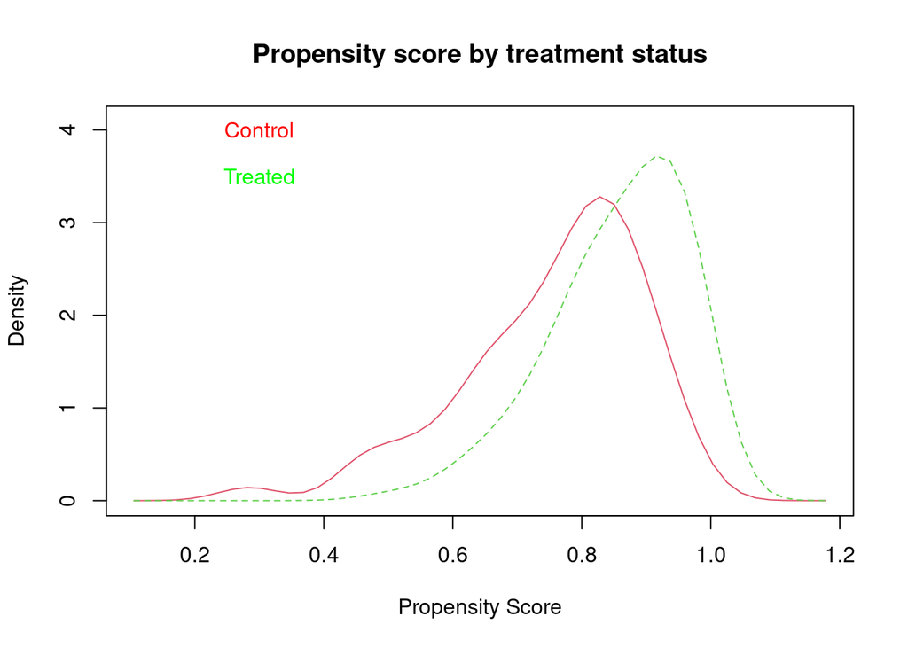

```r
require(sm)
sm.density.compare(ps.df$pr_score, ps.df$treat, xlab="Propensity Score")
title(main="Propensity score by treatment status")
text(0.3,4, "Control", col="red")
text(0.3,3.5, "Treated", col="green")
```

We can see that treated observations are associated with a larger propensity score than untreated units. This is what we would expect. Moreover, there is a significant *overlap*: For a large range of propensity scores there are both treated and untreated units. A better overlap could likely be achieved if the number of units in the control group were larger.

We are going to use `Matching`, a package with two important functions:

- The `MatchBalance()` function gives you balance before and after matching
- The `Match()` performs propensity score and distance (i.e. mahalanobis) Matching

Before we start our analysis, let’s check balance *before matching* with this package. Let’s use the `MatchBalance()` to do so. The syntax is the following: `MatchBalance(treat assignment variable ~ covariates, data= dataset)`. We will later include the `match.out` argument into this function to compare balance before and after matching.

```r
bal.bm=MatchBalance(treat~ repub + srvlng + female + white + age +
                  demvote + totchi + reld3 ,data=daughters)
```

[output not shown]

What does this tell us?

Now, let’s match! We use propensity score matching (PSM). By default, we estimate NN – so what does this mean? NN sets $C(\bar{P}_i)=min|\bar{P_i}-\bar{P}_j|$. Basically, the non-treated $\bar{P}_j$ closest to our treated unit $\bar{P}_i$ will be selected as a match. The estimator has the option to perform matching with or without replacement. We will first conduct matching without replacement. It’s important to know though that this method has the disadvantage that the final estimate will usually depend on the initial ordering of the treated observations for which the matches were selected.

Let’s start with **Step 1** of our list: Run a logit or probit with the treatment as outcome. To retrieve the propensity score, we estimate a logit model predicting assignment to treatment – just what we did above in `pre_matching`. We’ll call this `ps` although it’s exactly the same model as `pre_matching` - so feel free to just use the latter.

**Exercise 13: regress treatment variable `treat` on `totchi`, `repub`, `srvlng`, `female`, `white`, `age`, `demvote`, and `reld3`. using the `glm()` function. The syntax is the following: `glm(treatment assignment variable ~ covariate 1 + covariate 2...covariate n, data = data, family = binomial("logit"))`. Store the output from the `glm()` function into an object called `ps`.**

**Reveal Answer**

```r
ps <- glm(treat ~ repub + srvlng + female + white +
                age + demvote + reld3 + totchi ,    data    = daughters,    family  = binomial("logit"))
```

Next, we are going to match each treatment observation with a untreated unit, without replacement (that means, we are only going to use unique pairs of treatment-control, by contrast to matching with replacement, where the same individual can serve as control for several treated units). Let’s use the `Match()` function!

The syntax is the following: `Match(Y = df$outcome, Tr = df$treat, X = ps$fitted, replace = FALSE)`.

When we set the `replace` argument equal to `FALSE` we are setting our matching algorithm without replacement. The second argument of this function is treatment status (`Tr`), which has to be equal to the treatment assignment variable (`daughters$treat`). The `X` is the argument that determines the vector that will use to match the units. When we are conducting PSM, we set `X` equal to the propensity score obtained from the predicted values from the logistic regression `ps$fitted`.

**Exercise 14: Conduct matching using `Match()` without replacement. Match using propensity scores. Store the output of the `Match()` function into an object. Then, use `summary()` function to report the results. We need to set a seed to replicate our results. Set a seed equal to 1111 `set.seed(1111)`. This allows you to replicate results whenever random numbers are involved.**

**Reveal Answer**

```r
set.seed(1111)
match.ps<- Match(Y=daughters$nowtot, Tr=daughters$treat,    X=ps$fitted, replace=FALSE)
summary(match.ps)
```

```
Estimate...  -0.16949
SE.........  6.5292
T-stat.....  -0.025959
p.val......  0.97929

Original number of observations..............  371
Original number of treated obs...............  312
Matched number of observations...............  59
Matched number of observations  (unweighted).  59
```

We got that our point estimate for our ATT is `-0.17` - which is not statistically significant. Is this a robust result based on appropriate matching?  
Let’s first compare this point estimate to the regression estimates from OLS.

**Exercise 15: Using the `lm()` function, regress `nowtot` on the indepent variables `treat`, `totchi`, `repub`, `srvlng`, `female`, `white`, `age`, `demvote`, and `reld3`.Store the output from `lm()` into an object. Use the summary function `summary()` to report the results. What is the estimate for the `treat` variable?**

**Reveal Answer**

```r
multivariate <- lm(nowtot ~ treat + totchi + repub + srvlng + female + white + age + demvote + reld3, data=daughters)

summary(multivariate)
```

```
Call:
lm(formula = nowtot ~ treat + totchi + repub + srvlng + female +
    white + age + demvote + reld3, data = daughters)

Residuals:
    Min      1Q  Median      3Q     Max
-52.052  -9.092   0.325   8.907  59.732

Coefficients:
             Estimate Std. Error t value Pr(>|t|)
(Intercept)   6.00863   10.22942   0.587   0.5573
treat         4.09385    2.45198   1.670   0.0959 .
totchi       -1.35926    0.68149  -1.995   0.0468 *
repub       -46.88293    2.25988 -20.746  < 2e-16 ***
srvlng        0.03889    0.14183   0.274   0.7841
female       12.84109    2.83150   4.535 7.85e-06 ***
white         7.94178    3.33734   2.380   0.0178 *
age           0.04104    0.12479   0.329   0.7424
demvote     100.64213   10.64798   9.452  < 2e-16 ***
reld3        -4.79761    1.98234  -2.420   0.0160 *
---
Signif. codes:  0 '***' 0.001 '**' 0.01 '*' 0.05 '.' 0.1 ' ' 1

Residual standard error: 16.55 on 361 degrees of freedom
Multiple R-squared:  0.8026,    Adjusted R-squared:  0.7977
F-statistic: 163.1 on 9 and 361 DF,  p-value: < 2.2e-16
```

We see that the point estimates substantially differ. From matching using nearest neighbour without replacement we got `-0.17`, whereas from OLS we got `4.09`, being significant at the 90% level.

Now that we’ve done the matching, let’s check balance anew. For that, let’s use the `MatchBalance()` function. Recall the syntax is the following: `MatchBalance(treat assignment variable ~ covariates, data= dataset)`, but now let’s include the `match.out` argument into the function, so we can check balance before and after matching, i.e. `MatchBalance(treat assignment variable \~ covariates, match.out = output Match, data= dataset)`.

**Exercise: 16: Check for balance using the `MatchBalance()` for the Nearest Neighbour matching without replacement.**

**Reveal Answer**

```r
bal.ps=MatchBalance(treat~ repub + srvlng + female + white + age + demvote + totchi + reld3,
                    match.out=match.ps,data=daughters)
```

```
***** (V1) repub *****
                       Before Matching       After Matching
mean treatment........    0.53846           0.54237
mean control..........    0.49153           0.49153
std mean diff.........        9.4            10.119

mean raw eQQ diff.....   0.050847          0.050847
med  raw eQQ diff.....          0                 0
max  raw eQQ diff.....          1                 1

mean eCDF diff........   0.023468          0.025424
med  eCDF diff........   0.023468          0.025424
max  eCDF diff........   0.046936          0.050847

var ratio (Tr/Co).....    0.98066            0.9931
T-test p-value........    0.51323           0.54963


***** (V2) srvlng *****
                       Before Matching       After Matching
mean treatment........     8.5865            7.5085
mean control..........      10.78             10.78
std mean diff.........    -29.042           -50.866

mean raw eQQ diff.....     2.1525            3.2712
med  raw eQQ diff.....          2                 2
max  raw eQQ diff.....          8                18

mean eCDF diff........   0.061969          0.088512
med  eCDF diff........   0.060354          0.084746
max  eCDF diff........    0.13521           0.23729

var ratio (Tr/Co).....    0.54418           0.39465
T-test p-value........    0.12162          0.027254
KS Bootstrap p-value..      0.158             0.036
KS Naive p-value......    0.32452          0.072155
KS Statistic..........    0.13521           0.23729


***** (V3) female *****
```

[output cut: 106 more lines]

```
max  raw eQQ diff.....          0                 1

mean eCDF diff........ 0.00062473         0.0084746
med  eCDF diff........ 0.00062473         0.0084746
max  eCDF diff........  0.0012495          0.016949

var ratio (Tr/Co).....    0.98906            1.0378
T-test p-value........    0.98437           0.82796


Before Matching Minimum p.value: < 2.22e-16
Variable Name(s): totchi  Number(s): 7

After Matching Minimum p.value: 4.1336e-06
Variable Name(s): totchi  Number(s): 7
```

After matching, we are unable to achieve balance for the `totchi` covariate. [Why?]

We can see that the `MatchBalance` reports four difference sets of balance statistics for each variable. It contains the means of each group, standardised empirical quantile-quantile plots or so-called empirical-QQ plots (these plots depict if two datasets come from the same population with a common distribution), with `MatchBalance()` reporting summary statistics from the raw empirical-QQ plots. The output also provides summary statistics of the Empirical Cumulative Distribution Function (eCDF), which is the formal name of a cumulative distribution of a sample. Finally, it provides variance ratio of the treatment over the control, and the t test of difference in means as well as KS-statistics for continuous variables.

Visualisation helps here. We can plot a balance plot using the `love.plot()` and `bal.tab()` function. The `bal.tab()` function calculates the standardised difference in means. The `love.plot()` function generates a plot that displays covariate balance before and after matching. Some of the arguments are `stat` which determines what statistics you want to report: one common option is `mean.diffs` which reports the mean differences for each covariate. We can set a `threshold` at an optional value. We can also set that the statistics presented to absolute values by adding the `abs` function equal `TRUE`. Finally, we can also set the order of which the statistics are presented by including the `var.order` argument. If we set `var.order` equal to “unadjusted” the statistics will be ordered by the balance statistic of the unadjusted sample. See the example below. Always remember to add the object of the `Match()` function as the first argument of the `bal.tab()` function.

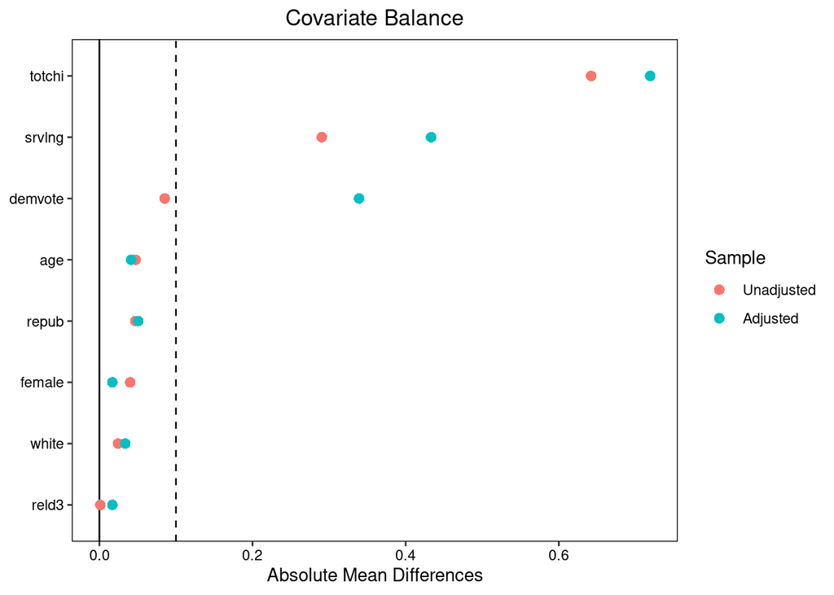

```r
love.plot(bal.tab(match.ps, treat~ repub + srvlng + female + white + age + demvote + totchi + reld3,
                  data = daughters),stat = "mean.diffs",
          threshold = .1, var.order = "unadjusted" ,abs=T)
```

Ideally, all covariates would be on the 0 line - as a rule of thumb, differences should not exceed 0.1 standardised mean differences. The further away the absolute mean differences are, the worse the balance. Now we have seen what happens with the means of the covariates. Let’s see next what happens with their distributions. Remember, it can well be that the means are the same but the distributions are statistically different. We’ll test that like we did last time with a Kolomogorov-Smirnov Statistic.

**Exercise 17: Check for balance using the `MatchBalance()` for the Nearest Neighbour matching without replacement, but rather than reporting mean differences, check for balance in their cumulative distribution by setting `stat = "ks.statistics"`.**

**Reveal Answer**

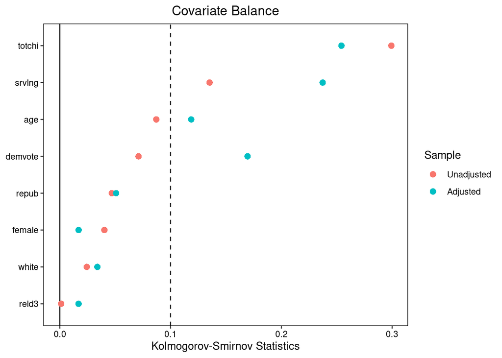

```r
love.plot(bal.tab(match.ps, treat~ repub + srvlng + female + white + age + demvote + totchi + reld3,
                  data = daughters),stat = "ks.statistics",
          threshold = .1, var.order = "unadjusted" ,abs=T)
```

Again, ideally everything would be on 0 (that would mean the covariate distributions are identical between the treatment and the control). Note also that kolomogorov-smirnov statistics only provide meaningful information for continuous covariates (while it defaults back to mean differences for binary variables).

The balance here is really bad - for some variables even worse than before matching! This doesn’t seem like the model we want to base our analysis on! In other words, we need a better approach.

### Propensity Score, With Replacement

Now, let’s use propensity score **with** replacement. Remember, this means that a single control unit can be matched to several treated units. Matching without replacement can yield very bad matches if the number of comparison observations comparable to the treated observations is small.

**How many neighbours should you use? It’s usually better to oversample – use more neighbours. This, however, involves a trade-off between bias and variance. If we match with replacement, we reduce bias at the cost of higher variance. Generally, in choosing between different matching estimators, the one with the best balance is the most preferable one.**

To do matching with replacement we only need to change set the argument `replace` of the `Match()` function equal to `TRUE`. Let’s run Matching with replacement.

**Exercise 18: Conduct Matching using the `Match()` function, but set the `replace` argument equal to `TRUE`. Use the `summary()` to report your results. Interpret the output from the `Match()` function. With matching with replacement, do you get closer to the multivariate regression benchmark? Do you think that matching with replacement leads to more or less bias than matching without replacement?. Does it lead to less or variance compared to matching without replacement? Remember to set the treatment status (`Tr`) function equal to `daughters$treat`. Set `X` equal to the propensity score obtained from the predicted values from the logistic regression `ps$fitted`.**

**Reveal Answer**

```r
match.ps2 <- Match(Y=daughters$nowtot,  Tr=daughters$treat, X=ps$fitted,
                  replace=T)

summary(match.ps2)
```

```
Estimate...  -3.9583
AI SE......  9.5929
T-stat.....  -0.41263
p.val......  0.67988

Original number of observations..............  371
Original number of treated obs...............  312
Matched number of observations...............  312
Matched number of observations  (unweighted).  316
```

Regarding the output from the `Match()` function, we now also have **AI SE** which is the matching corrected standard error ([**Abadie and Imbens, 2022**](https://www.nber.org/papers/t0283)). The T-stat and p.val are the standard t-test and p-value of the point estimate and they are interpreted as usual.

**The variance-bias trade off can be summarised as follows: Matching with replacement has the advantage of always matching each treated unit to the closest untreated unit, therefore reducing bias as compared to matching without replacement (in the latter case, remaining control units may be the best available - but not actually a good - match. On the other hand, variance is increased for matching with replacement as the estimates might be highly contingent on a small number of observations, whereas matching without replacement exhibits lower variance.**

**Exercise 19: Let’s check if we actually achieved balance using the `MatchBalance()` function on a set of covariates. One thing that we need to do is subset our data so we can conduct our balance test using a data frame that contains only covariates. Let’s drop the outcome variables and some covariates from the analysis. Let’s also remove columns 1, 9, 10, 11, 12, 14 which are either outcomes or are variables that have been created as a function of other variables. You can use the squared brackets to remove these columns. You can use the following syntax: data.frame[ ,-c(1,9:12, 14)]. Alternatively, directly specify the variables you want to test. Then, use the `bal.tab()` function to report the covariate balance. The syntax is the following: `bal.tab(object output Match function, treatment assignment variable ~ covariates, data = dataframe (excluding columns 1,9,10,11, 12 and 14))`. Remember to install/load the `cobalt` library to use the `bal.tab()` function. Identify for which variables there is imbalance before and after matching.**

**Reveal Answer**

```r
balancepost=MatchBalance(treat~., match.out=match.ps2, data=daughters[,-c(1, 9:12, 14)])
```

Let’s see the results using the `bal.tab()` function

```r
bal.tab(match.ps2, treat~., data=daughters[,-c(1, 9:12, 14)])
```

Now plot a balance plot for Matching with **replacement**.

**Exercise 20: Generate a balance plot before and after matching using the `love.plot()` and `bal.tab()` functions . Include the following arguments into the function: Set the `stat` argument equal to “variance.ratios”. As you may imagine, balance ratios are essentially the ratio of the variance of a covariate for the treated group over the variance of the same covariate for the control group. Also, let’s set the order of the variables by the size of the variance ratio for the adjusted measures by setting the `var.order` argument equal to “adjusted”. Also set the `abs` argument equal to `TRUE`.**

**Reveal Answer**

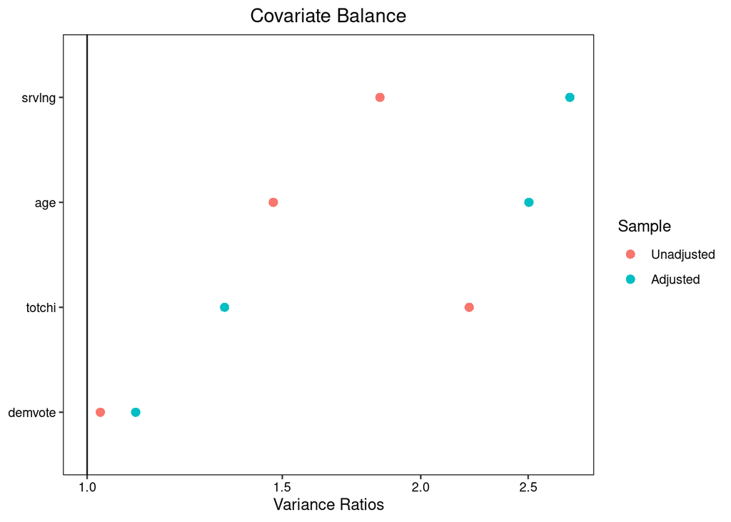

```r
daughters_cov=daughters[,-c(1, 9:12, 14)]

love.plot(bal.tab(match.ps2, treat~., data=daughters[,-c(1, 9:12, 14)]), stat = "variance.ratios", var.order = "adjusted", abs = TRUE)
```

We are using variance ratios as an example here to avoid repition. Feel free to select another statistic (such as mean differences) as well to double check.

We don’t see to much improvement in terms balance for variance - again, balance is much worse for some variables *after* matching. We need to do better.

### Caliper Matching

So far, the closest we’ve got to the multivariate regression benchmark has been using matching without replacement. Let’s try **Caliper Matching** now. Caliper Matching is a variant of Nearest Neighbour matching that attempts to avoid ‘bad’ matches ($\bar{P}_j$ that are far from our $\bar{P}_i$). In order to do this, Caliper Matching imposes a tolerance on the maximum distance between treated and untreated units - in other words, a limit as to how bad of a match we are willing to accept. If, for some participants, no matches are found within the specified caliper (distance) then they will be excluded from the analysis. Theoretically, Caliper should be better than pure NN, since it corrects for ‘bad’ matches.

Using a caliper should improve the quality of matching and also enforces common support because untreated units far from the treated units are discarded.

Let’s estimate Caliper with a distance of 0.1 standard deviations (of the propensity score).

**Exercise 21: Perform matching setting a caliper of 0.1. To do this, add the following argument to the `Match()` function: `caliper = 0.1`. Remember to place a comma between the arguments. Set the argument `replacement` equal to `FALSE` (or `F`). Use the `summary()` function to report your results.**

**Reveal Answer**

```r
match.ps.cal0.1=Match(Y=daughters$nowtot,   Tr=daughters$treat,
                          X=ps$fitted, caliper=0.1, replace=F)
summary(match.ps.cal0.1)
```

```
Estimate...  4.7273
SE.........  6.9549
T-stat.....  0.6797
p.val......  0.49669

Original number of observations..............  371
Original number of treated obs...............  312
Matched number of observations...............  55
Matched number of observations  (unweighted).  55

Caliper (SDs)........................................   0.1
Number of obs dropped by 'exact' or 'caliper'  257
```

We got`4.73` That’s ‘better’ than before (assuming that there is, in fact, a positive effect of having daughters), even though not significant. At least we got a positive coefficient. Note that the number of matched observations has decreased by only four observations as opposed to matching without replacement and without a caliper (considering the dramatic change in our estimated coefficient, these must have been pretty bad matches). How’s the balance though?

**Exercise 22: Perform a balance check using the `MatchBalance()` function. Include the following variables: “repub”, “srvlng”, “female”, “white”, “age” , “totchi”, “demvote”,“reld3”. Identify which variables are balanced before and after matching. Remember to store the output from the `Match()` function into a new object. Then set the argument `match.out` equal to new output.**

**Reveal Answer**

```r
bal.ps.cal0.1=MatchBalance(treat~ repub + srvlng + female + white + age +
             demvote + reld3 + totchi,
             match.out=match.ps.cal0.1,data=daughters)
```

**Exercise 23: Again, plot the results of your balance covariate evaluation as you did before. Use the `love.plot(bal.tab(....))` functions to generate this plot. Report the difference in means by setting `stat = "mean.diffs"`. Include a threshold by adding the `threshold` argument equal to .1. Order the unadjusted difference in means in a decreasing order by adding the argument `var.order = "unadjusted"`. Finally, include the `abs = TRUE` argument, so you report only absolute values of the difference in means. This is the syntax putting everything together: `love.plot(bal.tab(output matching, treat variable + covariates, data = data, stat= "means.diffs", threshold = .1, var.order = "unadjusted, abs = T)`.**

**Reveal Answer**

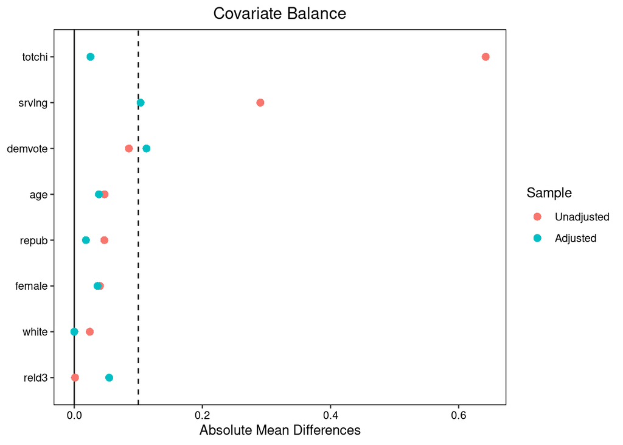

```r
love.plot(bal.tab(match.ps.cal0.1, treat ~ repub + srvlng + female + white + age +  demvote + reld3 + totchi,
                  data = daughters),stat = "mean.diffs",
          threshold = .1, var.order = "unadjusted" ,abs=T)
```

This looks pretty decent - importantly, we were able to achieve balance with the critical `totchi` variable! Even if not perfect, this is something one could work with - note the improvement as compared to previous balance plots! Finally, we achieve balance in most of the covariates!

**Exercise 24: Try again by changing the caliper equal to 0.25. Perform matching using the `Match()` function. Do this matching without replacement, so set the `replace` argument equal to `FALSE` (`F`).**

**Reveal Answer**

```r
match.ps.cal25 <- Match(Y = daughters$nowtot, Tr = daughters$treat, X = ps$fitted,
                        caliper = 0.25, replace = F)

summary(match.ps.cal25)
```

```
Estimate...  4.6364
SE.........  6.8669
T-stat.....  0.67517
p.val......  0.49957

Original number of observations..............  371
Original number of treated obs...............  312
Matched number of observations...............  55
Matched number of observations  (unweighted).  55

Caliper (SDs)........................................   0.25
Number of obs dropped by 'exact' or 'caliper'  257
```

Note also that our findings from caliper matching indicate that *NN matching* included quite a lot of matches of observations that were rather distinct in terms of their proposensity scores: While they were the nearest available neighbours, they were not actually *good neighbours*. Being aware of the **variance-bias trade-off**, it seems that *NN matching* (without replacement) did decrease the variance by introducing a meaningful bias.

**Exercise 25: Let’s examine again how well the matching procedure did in producing balance. Check for balance using the `MatchBalance()` function. Remember to store the output of the `Match()` function into an object and replace this object equal to the `match.out` argument.**

**Reveal Answer**

```r
# let's check for balance before and after matching using a 0.25 caliper.

bal.ps.cal25 = MatchBalance(treat ~ repub + srvlng + female + white + age +
                            demvote + reld3 + totchi,
                            match.out = match.ps.cal25, data = daughters)
```

```
***** (V1) repub *****
                       Before Matching       After Matching
mean treatment........    0.53846           0.54545
mean control..........    0.49153           0.52727
std mean diff.........        9.4            3.6181

mean raw eQQ diff.....   0.050847          0.018182
med  raw eQQ diff.....          0                 0
max  raw eQQ diff.....          1                 1

mean eCDF diff........   0.023468         0.0090909
med  eCDF diff........   0.023468         0.0090909
max  eCDF diff........   0.046936          0.018182

var ratio (Tr/Co).....    0.98066           0.99469
T-test p-value........    0.51323           0.84218


***** (V2) srvlng *****
                       Before Matching       After Matching
mean treatment........     8.5865            9.7273
mean control..........      10.78            9.3455
std mean diff.........    -29.042            4.9089

mean raw eQQ diff.....     2.1525            1.0364
med  raw eQQ diff.....          2                 0
max  raw eQQ diff.....          8                 4

mean eCDF diff........   0.061969          0.034091
med  eCDF diff........   0.060354          0.027273
max  eCDF diff........    0.13521          0.090909

var ratio (Tr/Co).....    0.54418           0.82865
T-test p-value........    0.12162           0.78024
KS Bootstrap p-value..      0.138             0.846
KS Naive p-value......    0.32452           0.97691
KS Statistic..........    0.13521          0.090909


***** (V3) female *****
```

[output cut: 106 more lines]

```
med  eCDF diff........   0.026782          0.018182
max  eCDF diff........    0.29933          0.072727

var ratio (Tr/Co).....     2.2119            1.1826
T-test p-value........ 1.1455e-08           0.27295
KS Bootstrap p-value.. < 2.22e-16             0.716
KS Naive p-value...... 0.00027523           0.99864
KS Statistic..........    0.29933          0.072727


Before Matching Minimum p.value: < 2.22e-16
Variable Name(s): totchi  Number(s): 8

After Matching Minimum p.value: 0.27295
Variable Name(s): totchi  Number(s): 8
```

We find that balance for all covariates!

Below we have a table that summarises the results from all the matching techniques and the multivariate regression - note that we would only reject the null hypothesis based on the results of the multivariate regression. As we can see, Capiler matching did a relatively good job compared to the other matching techniques, if we believe the author’s findings and assume there is a true significant effect about the size of the OLS estimator. Pay attention to the random order of observations and the *variance-bias trade off* when doing matching. You should always look for balance in the covariates. If you can’t achieve balance, try a different approach or specification. Often, the output of different estimators will give you an idea of what is ‘wrong’ with your data if you get vastly divergent results.

So why do matching? In this particular case, variance in the control group was high as we ended up with merely 59 control units. This makes matching more difficult, especially so when it comes to statistical significance. On the other hand, we can choose our estimator in a way that actually achieves balance in the covariates in under acceptable conditions with regard to theory. Recall that multivariate regression makes these decisions and comparisons implicitly. While not necessarily the case here, regressions may be off - and we may not even know that the approach is inadequate.

[output not shown]